# Exam 5 - Equilibrium and Fluids

**Date:** / /

**Class Number:** PHYS 1061 H002 **Instructor:** Michael Haas

**Name:**

Please read and follow all instructions carefully. Use the back of the sheet if necessary.

Definitions: (incompressible: not able to be compressed, incomprehensible: not able to be understood; not intelligible.)

Score: / 42 + Bonus: / 6 = Total: / 42 || Final: % -> [A, B, C, D, F]

Problem #1 (3 points)

What is the relationship between mass, volume, and density?

1. Density is inversely proportional to both mass and volume.
2. Density is proportional to both mass and volume.
3. Density is proportional to mass and inversely proportional to volume.
4. Density is inversely proportional to mass and proportional to volume.

Problem #2 (3 points)

Zaphod is holding two copies of the Hitchhiker's Guide to the Galaxy (same volume, same density) in a pool of liquid gallium. One of the guides (A) is held $2.00 \mathrm{in}$ below the surface and the other (B) is held at a depth of $1.50 \mathrm{ft}$. Which one experiences a greater buoyant force?

1. Both feel the same force.
2. Guide A.
3. Guide B.
4. Need more information.

Problem #3 (3 points)

Now A is held $2.00 \mathrm{in}$ below the surface in liquid gallium ($\rho_\mathrm{gallium} = 6.10E+03 \frac{\mathrm{kg}}{\mathrm{m}^{3}}$) and B is held $1.50 \mathrm{ft}$ under water ($\rho_\mathrm{water} = 1.00E+03 \frac{\mathrm{kg}}{\mathrm{m}^{3}}$), which one experiences a greater buoyant force?

1. Both feel the same force.
2. Guide A.
3. Guide B.
4. Need more information.

Problem #4 (3 points)

In the case of Guide B (($\rho_\mathrm{Guide} = 2.18E+03 \frac{\mathrm{kg}}{\mathrm{m}^{3}}$), $\mathrm{Depth}=1.50 \mathrm{ft}$), will it float up in either fluid?

1. Both.
2. Only gallium.
3. Only water.
4. Neither

Bonus #5 (3 points)

Define incompressible in an incomprehensible way.

Problem #6 (3 points)

Which of the following relates the density of an object with it's volume and force of buoyancy?

1. Pascal's principle.
2. Continuity equation.
3. Bernoulli's equation.
4. Newton's law.
5. Archimedes' principle.

Problem #7 (3 points)

For an airplane to achieve lift, the wing is formed into a particular shape. This causes the air above the wing to travel ______ resulting in a ______ pressure.

1. faster, lower
2. faster, higher
3. slower, lower
4. slower, higher

Problem #8 (3 points)

Five locations labeled A through E are indicated on the diagram. Which of these, if any, is a possible location of the object's center of mass (center of gravity)?

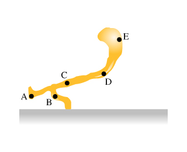

1. A
2. B
3. C
4. D
5. E

Bonus #9 (3 points)

Can you find any solutions to the equation $a^3 + b^3 = c^3$? How many are there?

Problem #10 (9 points)

The figure below shows a situation where a heterogeneous incompressible fluid is flowing through a pipe. The radii of the sections are $r_1=1.00 \mathrm{cm}$, $r_2=5.00 \mathrm{cm}$, $r_3=5.00 \mathrm{cm}$, $r_4=7.00 \mathrm{cm}$. Sections 3 and 4 are $3.00 \mathrm{cm}$ below sections 1 and 2. Choose one of the following to be the fluid in this problem: (Chocolate milk: $\rho_\mathrm{c} = 1.05E+03 \frac{\mathrm{kg}}{\mathrm{m}^{3}}$), (Maple Syrup: $\rho_\mathrm{m} = 1.37E+03 \frac{\mathrm{kg}}{\mathrm{m}^{3}}$), (Liquid Soap: $\rho_\mathrm{s} = 1.01E+03 \frac{\mathrm{kg}}{\mathrm{m}^{3}}$), (Fresh Orange Juice: $\rho_\mathrm{o} = 1.04E+03 \frac{\mathrm{kg}}{\mathrm{m}^{3}}$), (Vegetable Oil: $\rho_\mathrm{v} = 915. \frac{\mathrm{kg}}{\mathrm{m}^{3}}$)

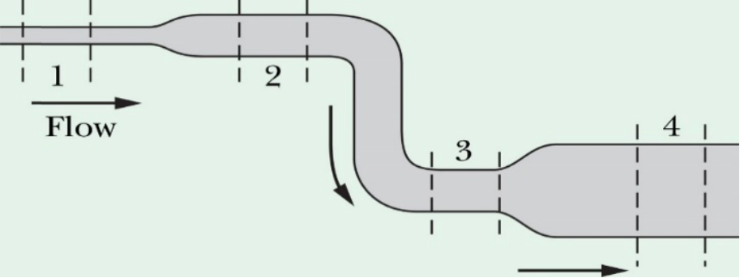

Question #1 (3 points)

Write down the relevant Bernoulli equation that relates sections 2 and and 4. Keep everything as variables and solve for the pressure in section 4.

Question #2 (3 points)

If the speed of the fluid in section 1 is $137. \frac{\mathrm{m}}{\mathrm{s}}$, what is the speed in section 2?

Question #3 (3 points)

The pressure in section 2 is $4.20 \mathrm{Pa}$, what is the pressure in section 3?

Problem #11 (12 points)

In the following figure, the bridge mass is $500. \mathrm{kg}$, the hanging object is $25.0 \mathrm{kg}$. The rope is attached to the bridge $\frac{4}{10}$ of the distance from the hinge, and the angle shown is $\phi=37.0 ^\circ$.

Question #1 (3 points)

Draw out all the forces acting on the bridge, rope, and hinge.

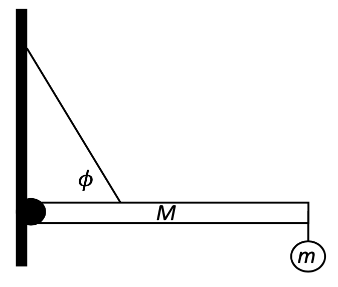

Question #2 (3 points)

Write down the equations needed to keep the bridge in equilibrium.

Question #3 (3 points)

Solve for the tension in the rope.

Question #4 (3 points)

What would the mass of the object need to be to snap the rope (it is made of a one inch nylon rope that has a breaking strength of $98.9 \mathrm{kN}$)?